# TechCrunch Analysis

Ivory Poo

2/14/2017

**Question 1**: Extract all articles from the TechCrunch main page of their web site. Create a data frame of these articles.

```r
library(rvest)
library(magrittr)
url <- read_html("https://techcrunch.com/")

#Scrape the website for the movie rating
title <- url %>%
  html_nodes(".post-title") %>%
  html_text() %>%
  as.character()

abstract <- url %>%
  html_nodes(".excerpt") %>%
  html_text() %>%
  as.character()

title_link <- url %>%
  html_nodes(".post-title a") %>%
  html_attr("href") %>%
  as.character()

#article=data.frame()

linktext<-function(x){
  url_title<- read_html(x)
  content <- url_title %>% html_nodes('.text')%>% html_text()%>%as.character()
  content=unlist(content)
}
#bag<-lapply(title_link, FUN=linktext)
bag=unlist(abstract)
bag <- gsub( "[\"(){}<>\r\n\t]", " ", bag)
bag<- gsub( "\\s+", " ", bag)
bag<- gsub( "… Read More", "", bag)
article=data.frame(matrix(bag, ncol=19, byrow=T))
#bag
#url_title<- html(title_link[1])
```

**Question 2**: Create a corpus of these articles, and then clean it of numbers, punctuation, stopwords, and stem the documents as well.

```r
library(tm)
text_corpus = Corpus(VectorSource(article))
#print(as.character(text_corpus[[1]]))
text_corpus_clean = tm_map(text_corpus,removeWords,stopwords("english"))
text_corpus_clean = tm_map(text_corpus_clean,removePunctuation)
text_corpus_clean = tm_map(text_corpus_clean,removeNumbers)
text_corpus_clean = tm_map(text_corpus_clean,stemDocument)
print(as.character(text_corpus_clean[[1]]))
```

```
## [1] "A newli publish video clip  Uber CEO Travi Kalanick may offer  world first glimps   think  busi  compet   rideshar juggernaut Read More"
```

**Question 3**: Create a term document matrix from the corpus and print the top 50 lines. What is the dimension of the TDM?

```r
tdm = TermDocumentMatrix(text_corpus_clean,control=list(minWordLength=1))
dim(tdm)
```

```
## [1] 442  19
```

```r
tdm_matrix=as.matrix(tdm)
tdm_matrix[1:50,]
```

```
##              Docs
## Terms         1 2 3 4 5 6 7 8 9 10 11 12 13 14 15 16 17 18 19
##   accid       0 0 0 0 0 0 0 0 0  0  0  1  0  0  0  0  0  0  0
##   account     0 0 0 0 0 0 0 0 0  0  0  0  0  0  0  0  0  1  0
##   achiev      0 0 0 0 0 0 0 0 0  0  0  0  0  0  0  0  1  0  0
##   actual      0 0 0 0 0 0 0 0 0  0  0  0  0  0  0  0  1  0  0
##   add         0 0 0 0 0 0 0 0 0  0  0  1  0  0  0  0  0  0  0
##   addit       0 0 1 0 0 0 0 0 0  0  0  0  0  0  0  0  0  0  0
##   adopt       0 0 0 0 0 0 0 0 0  0  0  0  0  1  0  0  0  0  0
##   after       0 0 0 0 1 0 0 0 0  0  0  0  0  0  0  0  0  0  0
##   agenda      0 0 0 0 0 0 0 0 0  0  1  0  0  0  0  0  0  0  0
##   ago         0 0 0 0 0 0 0 0 0  0  0  0  0  1  0  0  0  0  0
##   algorithm   0 0 0 0 0 0 0 0 0  0  0  0  0  0  0  0  0  1  0
##   along       0 0 0 0 0 0 0 0 0  0  0  1  0  0  0  0  0  0  0
##   alongsid    0 0 0 0 0 0 0 0 0  0  1  0  0  0  0  0  0  0  0
##   also        0 0 0 0 0 0 0 0 0  1  1  0  0  1  0  0  0  0  0
##   amazon      0 0 0 0 0 0 0 0 0  1  0  0  0  0  0  0  0  0  0
##   angellist   0 0 0 0 0 0 0 0 0  0  1  0  0  0  0  0  0  0  0
##   announc     0 0 0 0 0 0 0 0 1  0  0  0  0  0  1  0  1  1  0
##   another     0 0 0 0 0 0 1 0 0  0  0  0  0  0  0  0  0  0  0
##   apolog      0 0 0 0 0 1 0 0 0  0  0  0  0  0  0  0  0  0  0
##   app         0 0 2 0 0 0 1 0 0  2  0  0  0  0  0  0  0  2  0
##   appear      0 0 1 1 0 0 0 0 0  0  0  0  0  0  0  0  0  0  0
##   appli       0 0 0 0 0 1 0 0 0  0  0  0  0  0  0  0  0  0  0
##   applic      0 0 2 0 0 0 0 0 0  0  0  0  0  0  0  0  0  0  0
##   approach    0 0 0 0 0 0 0 0 0  0  1  0  0  0  0  0  0  0  0
##   arent       0 0 0 0 0 0 0 0 0  0  0  0  0  0  1  0  0  0  0
##   around      0 0 0 1 0 0 0 0 0  0  0  0  0  0  0  0  1  0  0
##   array       0 0 0 0 1 0 0 0 0  0  0  0  0  0  0  0  0  0  0
##   asset       0 0 0 0 0 0 0 1 0  0  0  0  0  0  0  0  0  0  0
##   attract     0 0 0 0 0 0 0 0 0  0  0  0  0  1  0  0  0  0  0
##   autom       0 0 0 0 0 0 0 0 0  0  0  1  0  0  0  0  0  0  0
##   automat     0 0 0 0 0 0 0 0 0  0  0  1  0  0  0  0  0  0  0
##   autonomi    0 0 0 0 0 0 0 0 0  0  0  1  0  0  0  0  0  0  0
##   avoid       0 0 0 0 0 0 0 0 0  0  0  1  0  0  0  0  0  0  0
##   aws         0 0 0 0 0 0 0 0 0  1  0  0  0  0  0  0  0  0  0
##   back        0 0 0 0 1 0 0 0 0  0  0  0  0  0  0  0  0  0  0
##   backend     0 0 0 0 0 0 0 0 0  1  0  0  0  0  0  0  0  0  0
##   barcelona   0 0 0 0 0 0 0 0 0  0  0  0  0  1  0  1  0  0  0
##   base        0 0 0 0 0 0 0 0 0  0  0  0  1  0  0  0  0  0  0
##   battlefield 0 0 0 0 0 2 0 0 0  0  0  0  0  0  0  0  0  0  0
##   bear        0 0 0 0 0 0 0 0 0  0  0  0  0  0  0  1  0  0  0
##   becam       0 0 0 0 0 0 0 0 0  0  0  0  1  0  0  0  0  0  0
##   becom       0 0 0 0 0 0 1 0 0  0  0  0  0  0  0  0  0  0  0
##   behalf      0 0 0 0 0 0 0 0 0  0  0  1  0  0  0  0  0  0  0
##   behind      0 0 0 0 0 0 0 0 0  0  0  0  0  0  1  0  0  0  0
##   believ      0 0 0 0 0 0 0 0 0  0  0  1  0  0  0  0  0  0  0
##   best        0 0 0 0 0 0 0 0 0  0  0  0  0  0  0  0  0  1  0
##   better      0 0 0 0 0 0 0 0 0  0  0  0  0  0  0  0  0  1  0
##   bit         0 0 0 0 0 0 0 0 0  0  0  0  0  0  0  1  0  0  0
##   blumberg    0 0 0 0 0 0 0 0 0  0  0  0  0  0  1  0  0  0  0
##   bmws        0 0 0 0 0 0 0 0 0  0  0  0  0  1  0  0  0  0  0
```

**Question 4**: From the TDM, make a network adjacency matrix of words. Assume two words are linked once if they appear in the same document. If they co-occur in say, three documents, then they are connected by strength 3. Based on co-occurrence withim documents, create the adjacency matrix of words, where the words are nodes, and their co-occurrences provide the data for the links.

```r
tdm_matrix[tdm_matrix>=1] <- 1    # change the TDM into Boolean matrix

# term adjacency matrix
term_matrix <- tdm_matrix %*% t(tdm_matrix)
term_matrix[1:10,1:10]
```

```
##          Terms
## Terms     accid account achiev actual add addit adopt after agenda ago
##   accid       1       0      0      0   1     0     0     0      0   0
##   account     0       1      0      0   0     0     0     0      0   0
##   achiev      0       0      1      1   0     0     0     0      0   0
##   actual      0       0      1      1   0     0     0     0      0   0
##   add         1       0      0      0   1     0     0     0      0   0
##   addit       0       0      0      0   0     1     0     0      0   0
##   adopt       0       0      0      0   0     0     1     0      0   1
##   after       0       0      0      0   0     0     0     1      0   0
##   agenda      0       0      0      0   0     0     0     0      1   0
##   ago         0       0      0      0   0     0     1     0      0   1
```

**Question 5**: Convert the Adjacency Matrix into a Edge List (This is just a two column listing of nodes from and nodes to.)

```r
library(igraph)
g <- graph.adjacency(term_matrix, weighted=T, mode = "undirected")
g <- simplify(g)
V(g)$label <- V(g)$name
V(g)$degree <- degree(g)
ed=get.edgelist(g, names=TRUE)
ed[1:10,]
```

```
##       [,1]    [,2]
##  [1,] "accid" "add"
##  [2,] "accid" "along"
##  [3,] "accid" "autom"
##  [4,] "accid" "automat"
##  [5,] "accid" "autonomi"
##  [6,] "accid" "avoid"
##  [7,] "accid" "behalf"
##  [8,] "accid" "believ"
##  [9,] "accid" "brake"
## [10,] "accid" "car"
```

**Question 6**: Using the edge list, create a spring force plot using D3. Redo the same plot, but zero out all edges which have value 1, and keep all edges with values 2 or greater. How different are the two plots, describe the difference.

Answer:The spring force plot with value 2 or greater are more scattered than the spring force plot with value 1 or greater.

```r
library(reshape2)
library(networkD3)
library(htmlwidgets)
```

```r
el <- melt(term_matrix)
el<-el[el$value!=0,]
colnames(el)<-c("V1","from","value")
term_number <- as.matrix(tdm$dimnames$Terms)
term_number <- as.data.frame(term_number)
term_number$code <- seq(1:length(term_number$V1))
el=merge(el,term_number,by="V1")
colnames(el)<-c("to","V1","value","to_code")
el=merge(el,term_number,by="V1")
colnames(el)<-c("to","from","value","to_code","from_code")
#subsetting to only the first 1000 terms
el_sub=el[1:1000,]
el1=el_sub[,3:5]
colnames(el1)<-c("value","target","source")
#nodes = data.frame(unique(el_sub$from, el_sub$to))
nodes = data.frame(term_number[,1])
names(nodes) = "name"
nodes$group = ceiling(3*runif(length(nodes$name)))
#create forcenetwork for orginal data
links1 = el1[,2:3]-1
links1$value = el1$value
y=forceNetwork(Links = links1, Nodes = nodes, Source = "source",
             Target = "target", Value = "value", NodeID = "name",
             Group = "group", opacity = 0.8, fontSize = 75)
saveWidget(y, file="\\springforceplot1.html")
y
```

[interactive chart not shown]

```r
#getting rid values 1

el2=el_sub[el_sub$value!=1,]
el3=el2[,3:5]
colnames(el3)<-c("value","target","source")
#nodes = data.frame(unique(el2$from, el2$to))
nodes = data.frame(term_number[,1])
names(nodes) = "name"
nodes$group = ceiling(3*runif(length(nodes$name)))
#create force network for orginal data
links2 = el3[,2:3]-1
links2$value = el3$value

x=forceNetwork(Links = links2, Nodes = nodes, Source = "source",
             Target = "target", Value = "value", NodeID = "name",
             Group = "group", opacity = 0.8, fontSize = 75)
```

```r
saveWidget(x, file="\\springforceplot2.html")
#please see the seperate file for the plot
x
```

[interactive chart not shown]

**Question 7**: Plot the degree distribution of your word network.

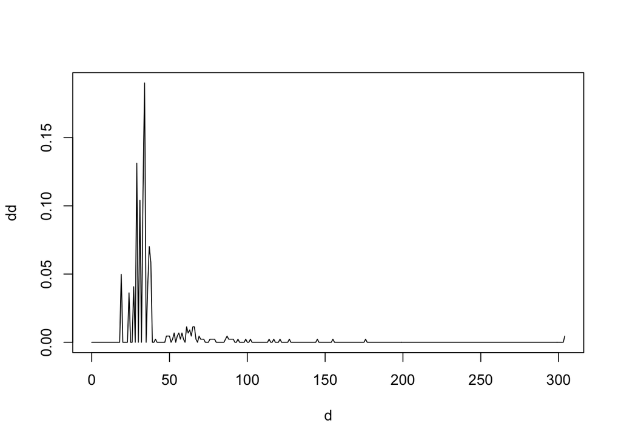

```r
dd = degree.distribution(g) # for each of the 30 nodes, what is the degree of connections
dd = as.matrix(dd)
d = as.matrix(seq(0,max(degree(g)))) #sequence of numbers of degree
plot(d,dd,type="l")
```

**Question 8**: Calculate the centrality of the words in the network. What are the top 10 central words? What conclusions can you state from this?

```r
cent = evcent(g)$vector
print("Normalized Centrality Scores")
```

```
## [1] "Normalized Centrality Scores"
```

```r
print(cent)
```

```
##          accid        account         achiev         actual            add
##     0.08566537     0.10572196     0.11382596     0.11382596     0.08566537
##          addit          adopt          after         agenda            ago
##     0.06522552     0.12963817     0.04163732     0.07910543     0.12963817
##      algorithm          along       alongsid           also         amazon
##     0.10572196     0.08566537     0.07910543     0.24730528     0.04574464
##      angellist        announc        another         apolog            app
##     0.07910543     0.34868621     0.09912350     0.01965690     0.30263080
##         appear          appli         applic       approach          arent
##     0.11397196     0.01965690     0.06522552     0.07910543     0.06365708
##         around          array          asset        attract          autom
##     0.16187670     0.04163732     0.05876545     0.12963817     0.08566537
##        automat       autonomi          avoid            aws           back
##     0.08566537     0.08566537     0.08566537     0.04574464     0.04163732
##        backend      barcelona           base    battlefield           bear
##     0.04574464     0.24799945     0.02553632     0.01965690     0.12196284
##          becam          becom         behalf         behind         believ
##     0.02553632     0.09912350     0.08566537     0.06365708     0.08566537
##           best         better            bit       blumberg           bmws
##     0.10572196     0.10572196     0.12196284     0.06365708     0.12963817
##          brake          bring         broken         bucket          build
##     0.08566537     0.02553632     0.04574464     0.02553632     0.05040159
##           busi           call       campaign         campus          capit
##     0.45337996     0.06522552     0.05040159     0.08067255     0.06365708
##            car         center            ceo            ces          chair
##     0.21222156     0.08067255     0.23759407     0.12963817     0.04163732
##          chang           chou     chromebook          circl          clear
##     0.10572196     0.05876545     0.12196284     0.05040159     0.02553632
##           clip          close          coffe        cofound        collect
##     0.18307088     0.17722234     0.04163732     0.05876545     0.06365708
##         collis           come        comment       communic        compani
##     0.08566537     0.02553632     0.11382596     0.06365708     0.32651954
##         compet         confer      conferenc       congress        context
##     0.18307088     0.10572196     0.06522552     0.24799945     0.04969677
##      continuum       cotswold          cours        credibl          crowd
##     0.08566537     0.08067255     0.12963817     0.09912350     0.04163732
##        current        curtain            dan        deadlin          decad
##     0.04969677     0.04163732     0.07910543     0.01965690     0.05876545
##         decemb          decid         declin       descript         design
##     0.05876545     0.01965690     0.02553632     0.06522552     0.06522552
```

[output cut: 123 more lines]

```
##     0.22878136     0.02553632     0.04574464     0.09912350     0.10572196
##        valuabl   vandermeyden         ventur           vice          video
##     0.09912350     0.04969677     0.06365708     0.24799945     0.28037707
##          vista           voic          volvo           wall          watch
##     0.04163732     0.07910543     0.08566537     0.01965690     0.09912350
##            way          wayup            web         webbas         websit
##     0.06365708     0.07910543     0.06522552     0.04574464     0.12694010
##          weiss           well           were         wessel          wheel
##     0.07910543     0.10381463     0.01965690     0.07910543     0.08566537
##        wherein    whitecollar     widespread           will           word
##     0.04969677     0.06365708     0.04574464     0.29174671     0.01965690
##           work       workforc        workjam          world           year
##     0.15319398     0.06365708     0.06365708     0.41907264     0.34055194
##            yet         youtub
##     0.06522552     0.04163732
```

```r
sorted_cent = sort(cent,decreasing=TRUE,index.return=TRUE)
Scent = sorted_cent$x
Scent[1:10]
```

```
##      more      read      busi     world       the       may   announc
## 1.0000000 1.0000000 0.4533800 0.4190726 0.4109880 0.3971868 0.3486862
##      year   compani      like
## 0.3405519 0.3265195 0.3213722
```

**Question 9**: Form “communities” of words, and state any regularities you may see from these communities. You may decide on the setting for the size of these communities as you prefer.

Answer: The regularity is that within each community, there appears to be a common theme. Some examples include:

Community 5: appears to be about financing companies, with terms such as ‘acquisit’, ‘marketplac’, ‘stock’

```r
wtc = walktrap.community(g)
res=membership(wtc)
print(res)
```

```
##          accid        account         achiev         actual            add
##              6              4              7              7              6
##          addit          adopt          after         agenda            ago
##              2              1             10              9              1
##      algorithm          along       alongsid           also         amazon
##              4              6              9              1             14
##      angellist        announc        another         apolog            app
##              9              4              5             13              1
##         appear          appli         applic       approach          arent
##              2             13              2              9              3
##         around          array          asset        attract          autom
##              7             10             15              1              6
##        automat       autonomi          avoid            aws           back
##              6              6              6             14             10
##        backend      barcelona           base    battlefield           bear
##             14              1             12             13              1
##          becam          becom         behalf         behind         believ
##             12              5              6              3              6
##           best         better            bit       blumberg           bmws
##              4              4              1              3              1
##          brake          bring         broken         bucket          build
##              6             12             14             12             11
##           busi           call       campaign         campus          capit
##              5              2             11             16              3
##            car         center            ceo            ces          chair
##              6             16              4              1             10
##          chang           chou     chromebook          circl          clear
##              4             15              1             11             12
##           clip          close          coffe        cofound        collect
##              2              5             10             15              3
##         collis           come        comment       communic        compani
##              6             12              7              3              2
##         compet         confer      conferenc       congress        context
##              2              4              2              1              8
##      continuum       cotswold          cours        credibl          crowd
##              6             16              1              5             10
##        current        curtain            dan        deadlin          decad
##              8             10              9             13             15
##         decemb          decid         declin       descript         design
##             15             13             12              2              2
```

[output cut: 123 more lines]

```
##              2             12             14              5              4
##        valuabl   vandermeyden         ventur           vice          video
##              5              8              3              1              2
##          vista           voic          volvo           wall          watch
##             10              9              6             13              5
##            way          wayup            web         webbas         websit
##              3              9              2             14              1
##          weiss           well           were         wessel          wheel
##              9              1             13              9              6
##        wherein    whitecollar     widespread           will           word
##              8              3             14              4             13
##           work       workforc        workjam          world           year
##              2              3              3              1              2
##            yet         youtub
##              2             10
```

```r
sort(res,decreasing=TRUE)
```

```
##         campus         center       cotswold          dyson        earlier
##             16             16             16             16             16
##         expans          focus           home     malmesburi          month
##             16             16             16             16             16
##         nearbi         offici           open           plan       research
##             16             16             16             16             16
##         second       singapor           tech          asset           chou
##             16             16             16             15             15
##        cofound          decad         decemb         euphor         experi
##             15             15             15             15             15
##          kabam          kevin          korea       netmarbl            run
##             15             15             15             15             15
##           sell          south         stress           talk         amazon
##             15             15             15             15             14
##            aws        backend         broken          devic            due
##             14             14             14             14             14
##         either          entir          error      experienc          fulli
##             14             14             14             14             14
##           high           imag         includ           lead           nest
##             14             14             14             14             14
##          outag        partial         provid           rate           reli
##             14             14             14             14             14
##           site         storag           upon         webbas     widespread
##             14             14             14             14             14
##         apolog          appli    battlefield        deadlin          decid
##             13             13             13             13             13
##     difficulti         extend      inconveni          march          might
##             13             13             13             13             13
##          notic            nys         resolv         spread           sure
##             13             13             13             13             13
##        technic       thursday            tri           wall           were
##             13             13             13             13             13
##           word           base          becam          bring         bucket
##             13             12             12             12             12
##          clear           come         declin         direct         divers
##             12             12             12             12             12
##           even        increas          intel          leaki           mean
##             12             12             12             12             12
##        midyear          minor         number         overal      represent
##             12             12             12             12             12
```

[output cut: 123 more lines]

```
##              1              1              1              1              1
##           like           line          littl           look            lot
##              1              1              1              1              1
##          maker           meet          mobil           name           news
##              1              1              1              1              1
##            now          offer         origin       osterloh          other
##              1              1              1              1              1
##          pixel        premium         presid        product           rick
##              1              1              1              1              1
##          right            sat         senior         servic          share
##              1              1              1              1              1
##          small        startup          today           vice         websit
##              1              1              1              1              1
##           well          world
##              1              1
```

**Question 10**: What is the diameter of the network? Why is this interesting?

```r
print(diameter(g))
```

```
## [1] 4
```